# Pecu-Group4-Slide

2017年1月7日

## 主題簡介

\[推廣太陽能發電，化專業資訊為易懂圖示\]

- 平易近人、簡單明瞭好上手
- 實用性高、與現行網站有區隔性
- 採用最新資料
- 分區較細
- 針對非商業使用者做好系統規劃

## 目錄

- 爬蟲-日照量與發電量
- 資料視覺化
- 推測、比較與評估
- 網頁實作

## 爬蟲-日照量與發電量

首先，我們上網查找政府相關部門公布之日照量與發電量。

- 日照量-中央氣象局
- 發電量-能源局

但由於政府官方網站並未有系統地公開多年記錄的資料，實際上我們是從各種網站及部落格一年一年地爬資料下來。

## 爬蟲-日照量與發電量

\[發電量資料來源：\]

- 100年 http://twpage5000.com/shinepvtech/knowledge.html
- 102年 http://www.solar2money.com/solar/how_much_solar_energy.html
- 103年 http://mrpv2.mynet.com.tw/information.php?sort_id=31
- 104年 http://www.taipower.com.tw/content/new_info/new_info-b49.aspx?LinkID=9

## 爬蟲-日照量與發電量

\[日照量資料來源：\]

- 96~100年 http://mrpv2.mynet.com.tw/uploads/20140212162503-1142442397.pdf
- 102~105年 http://e-service.cwb.gov.tw/HistoryDataQuery/index.jsp

## 爬蟲-發電量

利用 **readHTMLTable()** 函式抓取網頁中的table

範例：103年實際發電量

```
library(XML)
url103='http://mrpv2.mynet.com.tw/information.php?sort_id=31'
table103=readHTMLTable(url103)
knitr::kable(table103[[1]])
```

## 爬蟲-發電量

| V1 | V2 | V3 |
| --- | --- | --- |
| 縣市 | 年平均發電量 | 年度日平均發電量 |
|  | kWh/kWp | kWh/day/kWp |
| 基隆市 | 897 | 2.46 |
| 台北縣市 | 958 | 2.63 |
| 桃園縣 | 1058 | 2.90 |
| 新竹縣 | 1113 | 3.05 |
| 苗栗縣 | 1209 | 3.31 |
| 宜蘭縣 | 931 | 2.55 |
| 連江縣 | 1148 | 3.15 |
| 台中縣市 | 1205 | 3.30 |
| 彰化縣 | 1324 | 3.63 |
| 雲林縣 | 1269 | 3.48 |
| 南投縣 | 1142 | 3.13 |
| 嘉義縣 | 1231 | 3.37 |
| 花蓮縣 | 767 | 2.10 |
| 金門縣 | 1140 | 3.12 |
| 澎湖縣 | 1271 | 3.48 |
| 台南縣市 | 1285 | 3.52 |
| 高雄縣市 | 1204 | 3.30 |
| 屏東縣 | 1147 | 3.14 |
| 台東縣 | 969 | 2.66 |

## 爬蟲-日照量

日照量方面，各測站的資料都能從中央氣象局的網站取得，因此我們先把各測站所對應的URL碼整理成一csv檔，再讓R依據此檔案一一將資料爬下來。

由於R爬蟲教學影片是示範取得日照量的資料，因此這裡便不再贅述。

## 資料視覺化

將各年資料進行整理，用R的plot()函式作折線圖，顯示歷年來台灣各地發電量與日照量的變化

範例：以顏色表示不同地區，將所有資料彙集成一張圖表

```
solar <- read.csv("solar/solar_elec.csv")
sy<- solar[1:19,2:6]
sx <- c(100:104)
allc <- rainbow(20)
plot(sx, sy[1,], type='l',col=allc[1] , ylim=c(min(sy, na.rm=TRUE)*1.1, max(sy, na.rm=TRUE)*1.1), xlab="Year", ylab="Electrical energy", main="Annual solar-generated electrical energy between different counties")
for(i in 2:19){
  points(sx, sy[i,], pch=19, col=allc[i])
  lines(sx, sy[i,],col=allc[i])
}
```

## 資料視覺化

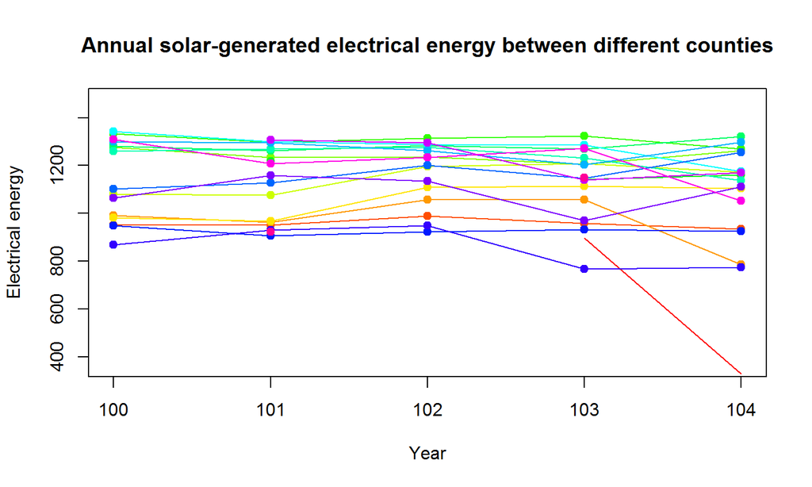

## 推測、比較與評估

\[推估發電量\]

- 以能源局及中央氣象局合作資料為推估依據
- 每 1 峰瓩(kWp)之年發電量為：「年發電量 × 1.08(發電面板接收輻射量為測站面板的1.08倍) × 1(kWp) × 75%(系統性能比)=ㄧ年總發電度數。
- 太陽能面板壽命至少20年，20年後的發電效率仍有原本之80%

## 推測、比較與評估

\[推測是否適合裝設\]

以日射量推估發電量，而非用實際發電量：

- 實際發電量-多為商用太陽能發電廠，發電效能、成本>適用於民眾的
- 日射量-資料源於氣象局測站，分區細，符合民眾需求
- 僅少部分無測站(日射量資料)之縣市改成由實際發電量推估

## 推測、比較與評估

十年可回本則適合裝設：

- 一般效能太陽能系統建置成本 80,000台幣/1 kWp(2~3坪空間)
- 十年保固
- 比較「各地的年均日射量」與「十年可回本之年日射量」，在不同顯著水準下檢驗是否相等：

適合-無顯著差異，回本時間等於十年。

普通(可自行考慮裝設)-顯著水準為0.05時，有顯著差異。

不適合-顯著水準為0.05、0.01時，皆顯著差異。

## 網頁實作

我們使用Bootstrap的模板當基礎，改良網頁切換的模式，並加上地圖、圖示等展現小組主題。

\[主要分成三大頁面：\]

- 首頁：介紹主題、成員，另有視覺化地圖連結
- 太陽能效益：顯示各地區的日照量、發電量與推估發電量，並給予相關之太陽能裝設建議
- 太陽能建置：太陽能發電小知識

https://chester11206.github.io/NTU_program4/

[figure not shown]